# Can Euklid tell a cat from a face?

We will load 2000 images of faces and compute the distribution of pairwise Euclidean distances among them. Then, we load 118 cat images, run each of them against every face image and compare the distribution of Euclidean distances with that of the faces themselves.

```python
from io import BytesIO
from zipfile import ZipFile
from urllib.request import urlopen

import numpy as np
import matplotlib.pyplot as plt
from PIL import Image

faces_url = 'http://www.cfpw.io/cfp-dataset.zip'
image_path_template = 'cfp-dataset/Data/Images/%03d/frontal/%02d.jpg'
num_persons = 200
faces_per_person = 10

cats_url = 'https://github.com/maxogden/cats/archive/master.zip'
cat_image_path_template = 'cats-master/cat_photos/kublai%d.jpg'
num_cats = 118
```

## Faces vs. Faces

Download the faces and show a random image.

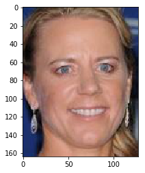

```python
resp = urlopen(faces_url)
zipfile = ZipFile(BytesIO(resp.read()))
with zipfile.open(image_path_template % (42, 1)) as f:
    image = Image.open(f)
    plt.imshow(image)
```

Resize each image to the same size and convert them to numpy arrays.

```python
faces = []
for i_person in range(1, num_persons + 1):
    for i_face in range(1, faces_per_person + 1):
        image_path = image_path_template % (i_person, i_face)
        with zipfile.open(image_path) as f:
            image = Image.open(f)
            image = image.resize((100, 100))
            faces.append(np.array(image))

faces = np.array(faces)
print('faces.shape: %s faces.dtype: %s' % (faces.shape, faces.dtype))
```

```
faces.shape: (2000, 100, 100, 3) faces.dtype: uint8
```

Compute the pairwise distances and plot them in a histogram.

```
Text(0,0.5,'Number of pairs')
```

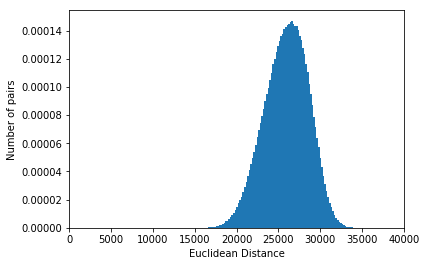

```python
# Compute the pairwise distances
face_distances = [np.linalg.norm(faces[a] - faces[b])
                  for a in range(len(faces)) for b in range(a)]

plt.hist(face_distances, bins=200, density=True)
plt.xlim(0, 40000)
plt.xlabel('Euclidean Distance')
plt.ylabel('Number of pairs')
```

Take a look at the pairwise distances computed for a single image.

```
Text(0,0.5,'Number of images')
```

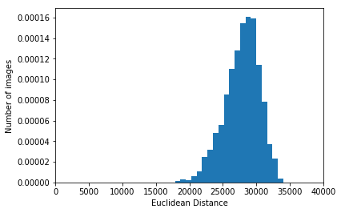

```python
face_single_distances = [np.linalg.norm(faces[a] - faces[410])
                         for a in range(len(faces)) if a != 410]
plt.hist(face_single_distances, bins=20, density=True)
plt.xlim(0, 40000)
plt.xlabel('Euclidean Distance')
plt.ylabel('Number of images')
```

## Cats vs. Faces

Download the cat images and show a random image

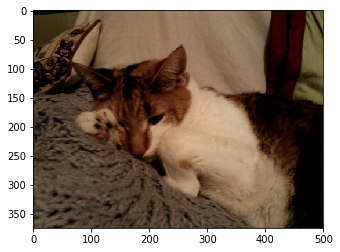

```python
resp = urlopen(cats_url)
zipfile = ZipFile(BytesIO(resp.read()))
with zipfile.open(cat_image_path_template % 5) as f:
    image = Image.open(f)
    plt.imshow(image)
```

Resize each image to the same size and convert them to numpy arrays.

```python
cats = []
for i_cat in range(1, num_cats + 1):
    image_path = cat_image_path_template % i_cat
    with zipfile.open(image_path) as f:
        image = Image.open(f)
        image = image.resize((100, 100))
        cats.append(np.array(image))

cats = np.array(cats)
print(cats.shape, cats.dtype)
```

```
(118, 100, 100, 3) uint8
```

Run a single cat image against all face images and plot the distribution of Euclidean distances.

```
Text(0,0.5,'Number of images')
```

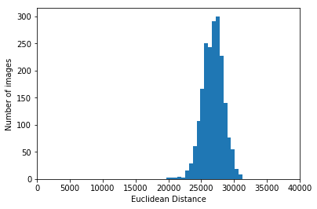

```python
cat_single_distances = [np.linalg.norm(face - cats[5])
                        for face in faces]
plt.hist(cat_single_distances, bins=20)
plt.xlim(0, 40000)
plt.xlabel('Euclidean Distance')
plt.ylabel('Number of images')
```

Run all cat images against all face images and plot the distribution of Euclidean distances

```python
# Compute the pairwise distances
cat_distances = [np.linalg.norm(face - cat)
             for cat in cats for face in faces]
```

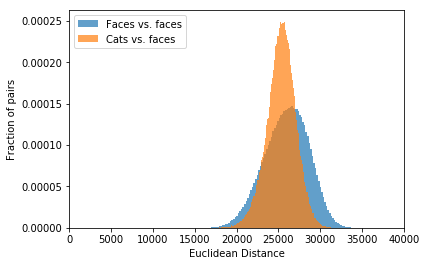

```python
plt.hist(face_distances, bins=200, density=True, alpha=0.7, label='Faces vs. faces')
plt.hist(cat_distances, bins=200, density=True, alpha=0.7, label='Cats vs. faces')
plt.xlim(0, 40000)
plt.xlabel('Euclidean Distance')
plt.ylabel('Fraction of pairs')
plt.legend()
```

## Conclusion

The distributions are only slightly different. The average cat image even seems to be closer to all face images than the average face image. Given the distribution of a single image at test time, it will therefore be hard to detect outliers / cats.